```python
import groups
%matplotlib inline
```

# Whitehead Graphs

To understand the Whitehead Algorithm, first you need to understand what *Whitehead Graphs* are. They are pretty simple, and its very easy to understand them once you play around with them a little bit. I have pictured below the Whitehead Graph for the word 'a'.

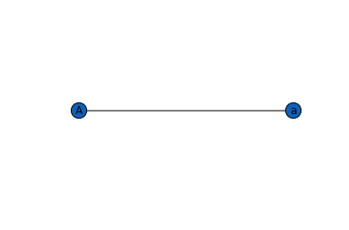

```python
groups.DrawGraphForWord('a')
```

Lets look at some more complex graphs.

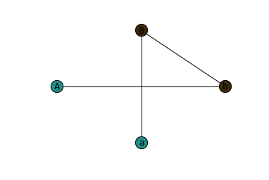

```python
groups.DrawGraphForWord('abb')
```

Lets break the word down into a bunch of pieces, two generator pieces. Because this is basically how the algorithm works, its super easy.

```python
word = 'abb'
edges = [(word[i],word[(i + 1)]) for i in range(0,len(word) - 1)] + [(word[len(word) - 1],word[0])]
print(edges)
```

```
[('a', 'b'), ('b', 'b'), ('b', 'a')]
```

You will note that there are 3 elements in the list, and 3 edges in the graph. However, the edges are *not* the elements of the list. They are just slightly off.

```python
print([(groups.Inverse(i),q) for (i,q) in edges])
```

```
[('A', 'b'), ('B', 'b'), ('B', 'a')]
```

And there we have it, the edges in our graph. That wasn't so complicated. So lets do a more complicated one.

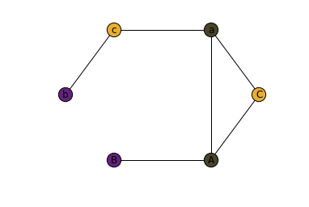

```python
groups.DrawGraphForWord('aBcAcaa')
```

That looks sufficiently complex. The amazing thing about the method of producing these, is that it is actually quite simple. I was able to produce the Whitehead Graph (not draw it) of a word in only 3 lines *(not including print(edges))*.

I'll draw some more just for fun

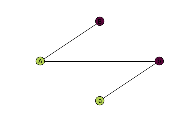

```python
groups.DrawGraphForWord('aBAb')
```

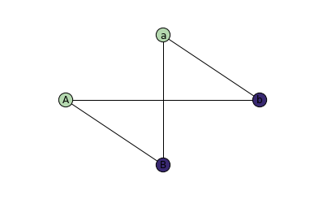

```python
groups.DrawGraphForWord('BaBA')
```

The current implimentation is not without problems unfortunately. As it currently stands, it does not draw MultiGraphs properly. Here is a graph that should have multiple edges between $a$ and $A$, but unfortunately, it does not.

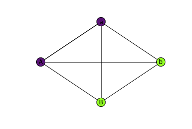

```python
groups.DrawGraphForWord('aabaaBB')
```

Other than that, it is an excellent Whitehead Graph drawing library.